# MODEL BUILDING IN EMPLOYEES ATTRITION DATASET

PREDICTION

# Predict attrition of your valuable employees

```python
#install/import packages libraries
from sklearn.metrics import make_scorer, accuracy_score # for accuracy
from sklearn.model_selection import train_test_split # for splitting the train-test data
from sklearn.ensemble import RandomForestClassifier # random forest model
from sklearn.linear_model import LogisticRegression # regression
from sklearn.linear_model import LinearRegression # regression
from sklearn.tree import DecisionTreeClassifier
from sklearn.metrics import classification_report # to create all accuracy matrices
from sklearn.model_selection import GridSearchCV,cross_val_score # hyper parameter optimization
from sklearn.metrics import confusion_matrix # cofusion matrix / accuracy
from sklearn.metrics import accuracy_score # accuracy score / accuracy
from sklearn import preprocessing # EDA
from datetime import datetime
import warnings
warnings.filterwarnings('ignore')
from sklearn import svm
from sklearn.linear_model import SGDClassifier
from sklearn.metrics import roc_auc_score
from sklearn.metrics import roc_curve
from sklearn.preprocessing import StandardScaler,LabelEncoder
from sklearn import decomposition
import matplotlib.pylab as pylab # visualization
import matplotlib.pyplot as plt # visualization
from pandas import get_dummies # EDA
import matplotlib as mpl  # visualization
import seaborn as sns # visualization
import pandas as pd # EDA
import numpy as np # EDA
import matplotlib # visualization
import warnings # EDA
import sklearn # machine learning
import scipy  # EDA
import json # EDA
import sys # EDA
import csv # EDA
import os # to work with the the work libraries / system related variables
import math
```

```python
# code to see the output of multiple lines of codes

from IPython.core.interactiveshell import InteractiveShell
InteractiveShell.ast_node_interactivity = 'all'
```

# Loading of dataset

```python
# LOADING THE FILE USING READ_CSV

attrn_data = pd.read_csv('C:/Users/SONY/Downloads/R Project - Attrition/Attrition.csv')
attrn_data
```

|  | Age | Attrition | BusinessTravel | DailyRate | Department | DistanceFromHome | Education | EducationField | EmployeeCount | EmployeeNumber | ... | RelationshipSatisfaction | StandardHours | StockOptionLevel | TotalWorkingYears | TrainingTimesLastYear | WorkLifeBalance | YearsAtCompany | YearsInCurrentRole | YearsSinceLastPromotion | YearsWithCurrManager |
| --- | --- | --- | --- | --- | --- | --- | --- | --- | --- | --- | --- | --- | --- | --- | --- | --- | --- | --- | --- | --- | --- |
| 0 | 41 | Yes | Travel_Rarely | 1102 | Sales | 1 | 2 | Life Sciences | 1 | 1 | ... | 1 | 80 | 0 | 8 | 0 | 1 | 6 | 4 | 0 | 5 |
| 1 | 49 | No | Travel_Frequently | 279 | Research & Development | 8 | 1 | Life Sciences | 1 | 2 | ... | 4 | 80 | 1 | 10 | 3 | 3 | 10 | 7 | 1 | 7 |
| 2 | 37 | Yes | Travel_Rarely | 1373 | Research & Development | 2 | 2 | Other | 1 | 4 | ... | 2 | 80 | 0 | 7 | 3 | 3 | 0 | 0 | 0 | 0 |
| 3 | 33 | No | Travel_Frequently | 1392 | Research & Development | 3 | 4 | Life Sciences | 1 | 5 | ... | 3 | 80 | 0 | 8 | 3 | 3 | 8 | 7 | 3 | 0 |
| 4 | 27 | No | Travel_Rarely | 591 | Research & Development | 2 | 1 | Medical | 1 | 7 | ... | 4 | 80 | 1 | 6 | 3 | 3 | 2 | 2 | 2 | 2 |
| ... | ... | ... | ... | ... | ... | ... | ... | ... | ... | ... | ... | ... | ... | ... | ... | ... | ... | ... | ... | ... | ... |
| 1465 | 36 | No | Travel_Frequently | 884 | Research & Development | 23 | 2 | Medical | 1 | 2061 | ... | 3 | 80 | 1 | 17 | 3 | 3 | 5 | 2 | 0 | 3 |
| 1466 | 39 | No | Travel_Rarely | 613 | Research & Development | 6 | 1 | Medical | 1 | 2062 | ... | 1 | 80 | 1 | 9 | 5 | 3 | 7 | 7 | 1 | 7 |
| 1467 | 27 | No | Travel_Rarely | 155 | Research & Development | 4 | 3 | Life Sciences | 1 | 2064 | ... | 2 | 80 | 1 | 6 | 0 | 3 | 6 | 2 | 0 | 3 |
| 1468 | 49 | No | Travel_Frequently | 1023 | Sales | 2 | 3 | Medical | 1 | 2065 | ... | 4 | 80 | 0 | 17 | 3 | 2 | 9 | 6 | 0 | 8 |
| 1469 | 34 | No | Travel_Rarely | 628 | Research & Development | 8 | 3 | Medical | 1 | 2068 | ... | 1 | 80 | 0 | 6 | 3 | 4 | 4 | 3 | 1 | 2 |

1470 rows × 35 columns

# Exploratory Data Analysis (EDA

# Summary and Analysis of datasets

```python
type(attrn_data)
attrn_data.head()


print('Describe')
attrn_data.describe()


print('INFO')
attrn_data.info()


print(attrn_data.shape)


print('COLUMNS')
attrn_data.columns
```

```
pandas.core.frame.DataFrame
```

|  | Age | Attrition | BusinessTravel | DailyRate | Department | DistanceFromHome | Education | EducationField | EmployeeCount | EmployeeNumber | ... | RelationshipSatisfaction | StandardHours | StockOptionLevel | TotalWorkingYears | TrainingTimesLastYear | WorkLifeBalance | YearsAtCompany | YearsInCurrentRole | YearsSinceLastPromotion | YearsWithCurrManager |
| --- | --- | --- | --- | --- | --- | --- | --- | --- | --- | --- | --- | --- | --- | --- | --- | --- | --- | --- | --- | --- | --- |
| 0 | 41 | Yes | Travel_Rarely | 1102 | Sales | 1 | 2 | Life Sciences | 1 | 1 | ... | 1 | 80 | 0 | 8 | 0 | 1 | 6 | 4 | 0 | 5 |
| 1 | 49 | No | Travel_Frequently | 279 | Research & Development | 8 | 1 | Life Sciences | 1 | 2 | ... | 4 | 80 | 1 | 10 | 3 | 3 | 10 | 7 | 1 | 7 |
| 2 | 37 | Yes | Travel_Rarely | 1373 | Research & Development | 2 | 2 | Other | 1 | 4 | ... | 2 | 80 | 0 | 7 | 3 | 3 | 0 | 0 | 0 | 0 |
| 3 | 33 | No | Travel_Frequently | 1392 | Research & Development | 3 | 4 | Life Sciences | 1 | 5 | ... | 3 | 80 | 0 | 8 | 3 | 3 | 8 | 7 | 3 | 0 |
| 4 | 27 | No | Travel_Rarely | 591 | Research & Development | 2 | 1 | Medical | 1 | 7 | ... | 4 | 80 | 1 | 6 | 3 | 3 | 2 | 2 | 2 | 2 |

5 rows × 35 columns

```
Describe
```

|  | Age | DailyRate | DistanceFromHome | Education | EmployeeCount | EmployeeNumber | EnvironmentSatisfaction | HourlyRate | JobInvolvement | JobLevel | ... | RelationshipSatisfaction | StandardHours | StockOptionLevel | TotalWorkingYears | TrainingTimesLastYear | WorkLifeBalance | YearsAtCompany | YearsInCurrentRole | YearsSinceLastPromotion | YearsWithCurrManager |
| --- | --- | --- | --- | --- | --- | --- | --- | --- | --- | --- | --- | --- | --- | --- | --- | --- | --- | --- | --- | --- | --- |
| count | 1470.000000 | 1470.000000 | 1470.000000 | 1470.000000 | 1470.0 | 1470.000000 | 1470.000000 | 1470.000000 | 1470.000000 | 1470.000000 | ... | 1470.000000 | 1470.0 | 1470.000000 | 1470.000000 | 1470.000000 | 1470.000000 | 1470.000000 | 1470.000000 | 1470.000000 | 1470.000000 |
| mean | 36.923810 | 802.485714 | 9.192517 | 2.912925 | 1.0 | 1024.865306 | 2.721769 | 65.891156 | 2.729932 | 2.063946 | ... | 2.712245 | 80.0 | 0.793878 | 11.279592 | 2.799320 | 2.761224 | 7.008163 | 4.229252 | 2.187755 | 4.123129 |
| std | 9.135373 | 403.509100 | 8.106864 | 1.024165 | 0.0 | 602.024335 | 1.093082 | 20.329428 | 0.711561 | 1.106940 | ... | 1.081209 | 0.0 | 0.852077 | 7.780782 | 1.289271 | 0.706476 | 6.126525 | 3.623137 | 3.222430 | 3.568136 |
| min | 18.000000 | 102.000000 | 1.000000 | 1.000000 | 1.0 | 1.000000 | 1.000000 | 30.000000 | 1.000000 | 1.000000 | ... | 1.000000 | 80.0 | 0.000000 | 0.000000 | 0.000000 | 1.000000 | 0.000000 | 0.000000 | 0.000000 | 0.000000 |
| 25% | 30.000000 | 465.000000 | 2.000000 | 2.000000 | 1.0 | 491.250000 | 2.000000 | 48.000000 | 2.000000 | 1.000000 | ... | 2.000000 | 80.0 | 0.000000 | 6.000000 | 2.000000 | 2.000000 | 3.000000 | 2.000000 | 0.000000 | 2.000000 |
| 50% | 36.000000 | 802.000000 | 7.000000 | 3.000000 | 1.0 | 1020.500000 | 3.000000 | 66.000000 | 3.000000 | 2.000000 | ... | 3.000000 | 80.0 | 1.000000 | 10.000000 | 3.000000 | 3.000000 | 5.000000 | 3.000000 | 1.000000 | 3.000000 |
| 75% | 43.000000 | 1157.000000 | 14.000000 | 4.000000 | 1.0 | 1555.750000 | 4.000000 | 83.750000 | 3.000000 | 3.000000 | ... | 4.000000 | 80.0 | 1.000000 | 15.000000 | 3.000000 | 3.000000 | 9.000000 | 7.000000 | 3.000000 | 7.000000 |
| max | 60.000000 | 1499.000000 | 29.000000 | 5.000000 | 1.0 | 2068.000000 | 4.000000 | 100.000000 | 4.000000 | 5.000000 | ... | 4.000000 | 80.0 | 3.000000 | 40.000000 | 6.000000 | 4.000000 | 40.000000 | 18.000000 | 15.000000 | 17.000000 |

8 rows × 26 columns

```
INFO
<class 'pandas.core.frame.DataFrame'>
RangeIndex: 1470 entries, 0 to 1469
Data columns (total 35 columns):
Age                         1470 non-null int64
Attrition                   1470 non-null object
BusinessTravel              1470 non-null object
DailyRate                   1470 non-null int64
Department                  1470 non-null object
DistanceFromHome            1470 non-null int64
Education                   1470 non-null int64
EducationField              1470 non-null object
EmployeeCount               1470 non-null int64
EmployeeNumber              1470 non-null int64
EnvironmentSatisfaction     1470 non-null int64
Gender                      1470 non-null object
HourlyRate                  1470 non-null int64
JobInvolvement              1470 non-null int64
JobLevel                    1470 non-null int64
JobRole                     1470 non-null object
JobSatisfaction             1470 non-null int64
MaritalStatus               1470 non-null object
MonthlyIncome               1470 non-null int64
MonthlyRate                 1470 non-null int64
NumCompaniesWorked          1470 non-null int64
Over18                      1470 non-null object
OverTime                    1470 non-null object
PercentSalaryHike           1470 non-null int64
PerformanceRating           1470 non-null int64
RelationshipSatisfaction    1470 non-null int64
StandardHours               1470 non-null int64
StockOptionLevel            1470 non-null int64
TotalWorkingYears           1470 non-null int64
TrainingTimesLastYear       1470 non-null int64
WorkLifeBalance             1470 non-null int64
YearsAtCompany              1470 non-null int64
YearsInCurrentRole          1470 non-null int64
YearsSinceLastPromotion     1470 non-null int64
YearsWithCurrManager        1470 non-null int64
dtypes: int64(26), object(9)
memory usage: 350.3+ KB
(1470, 35)
COLUMNS
```

```
Index(['Age', 'Attrition', 'BusinessTravel', 'DailyRate', 'Department',
       'DistanceFromHome', 'Education', 'EducationField', 'EmployeeCount',
       'EmployeeNumber', 'EnvironmentSatisfaction', 'Gender', 'HourlyRate',
       'JobInvolvement', 'JobLevel', 'JobRole', 'JobSatisfaction',
       'MaritalStatus', 'MonthlyIncome', 'MonthlyRate', 'NumCompaniesWorked',
       'Over18', 'OverTime', 'PercentSalaryHike', 'PerformanceRating',
       'RelationshipSatisfaction', 'StandardHours', 'StockOptionLevel',
       'TotalWorkingYears', 'TrainingTimesLastYear', 'WorkLifeBalance',
       'YearsAtCompany', 'YearsInCurrentRole', 'YearsSinceLastPromotion',
       'YearsWithCurrManager'],
      dtype='object')
```

Checking the missiong values

```python
def check_missing_data(attrn_data):
    flag=attrn_data.isna().sum().any()
    if flag==True:
        total = attrn_data.isnull().sum()
        percent = (attrn_data.isnull().sum())/(attrn_data.isnull().count()*100)
        output = pd.concat([total, percent], axis=1, keys=['Total', 'Percent'])
        data_type = []
        for col in attrn_data.columns:
            dtype = str(attrn_data[col].dtype)
            data_type.append(dtype)
        output['Types'] = data_type
        return(np.transpose(output))
    else:
        return(False)

check_missing_data(attrn_data)
#function for missing data
def missing_value(attrn_data):
    total = attrn_data.isnull().sum().sort_values(ascending=False)
    percent = (attrn_data.isnull().sum()/attrn_data.isnull().count()).sort_values(ascending=False)
    missing_data = pd.concat([total, percent], axis=1, keys=['Total', 'Percent'])
    return(missing_data.head(20))
missing_value(attrn_data)
```

```
False
```

|  | Total | Percent |
| --- | --- | --- |
| YearsWithCurrManager | 0 | 0.0 |
| EmployeeCount | 0 | 0.0 |
| JobLevel | 0 | 0.0 |
| JobInvolvement | 0 | 0.0 |
| HourlyRate | 0 | 0.0 |
| Gender | 0 | 0.0 |
| EnvironmentSatisfaction | 0 | 0.0 |
| EmployeeNumber | 0 | 0.0 |
| EducationField | 0 | 0.0 |
| JobSatisfaction | 0 | 0.0 |
| Education | 0 | 0.0 |
| DistanceFromHome | 0 | 0.0 |
| Department | 0 | 0.0 |
| DailyRate | 0 | 0.0 |
| BusinessTravel | 0 | 0.0 |
| Attrition | 0 | 0.0 |
| JobRole | 0 | 0.0 |
| MaritalStatus | 0 | 0.0 |
| YearsSinceLastPromotion | 0 | 0.0 |
| StandardHours | 0 | 0.0 |

REMOVING THE VARIABLES WHICH ARE NOT USEFUL

```python
data=attrn_data.drop(columns=['StandardHours','EmployeeCount','Over18'],axis=1)
data.columns
```

```
Index(['Age', 'Attrition', 'BusinessTravel', 'DailyRate', 'Department',
       'DistanceFromHome', 'Education', 'EducationField', 'EmployeeNumber',
       'EnvironmentSatisfaction', 'Gender', 'HourlyRate', 'JobInvolvement',
       'JobLevel', 'JobRole', 'JobSatisfaction', 'MaritalStatus',
       'MonthlyIncome', 'MonthlyRate', 'NumCompaniesWorked', 'OverTime',
       'PercentSalaryHike', 'PerformanceRating', 'RelationshipSatisfaction',
       'StockOptionLevel', 'TotalWorkingYears', 'TrainingTimesLastYear',
       'WorkLifeBalance', 'YearsAtCompany', 'YearsInCurrentRole',
       'YearsSinceLastPromotion', 'YearsWithCurrManager'],
      dtype='object')
```

Target variable

One final step that that we have to remember is to generate our target variable. The target in this case is given by the column Attrition which contains categorical variables therefore requires numerical encoding. We numerically encode it by creating a dictionary with the mapping given as 1 : Yes and 0 : No

Replacing the Attrition value into 1 and 0

```python
#data.Attrition.replace(to_replace=['no', 'yes'], value=[0, 1])
data.Attrition.replace(to_replace = dict(Yes = 1, No = 0), inplace = True)
```

```python
attrn_data1 = pd.get_dummies(data)
attrn_data1.info()
```

```
<class 'pandas.core.frame.DataFrame'>
RangeIndex: 1470 entries, 0 to 1469
Data columns (total 53 columns):
Age                                  1470 non-null int64
Attrition                            1470 non-null int64
DailyRate                            1470 non-null int64
DistanceFromHome                     1470 non-null int64
Education                            1470 non-null int64
EmployeeNumber                       1470 non-null int64
EnvironmentSatisfaction              1470 non-null int64
HourlyRate                           1470 non-null int64
JobInvolvement                       1470 non-null int64
JobLevel                             1470 non-null int64
JobSatisfaction                      1470 non-null int64
MonthlyIncome                        1470 non-null int64
MonthlyRate                          1470 non-null int64
NumCompaniesWorked                   1470 non-null int64
PercentSalaryHike                    1470 non-null int64
PerformanceRating                    1470 non-null int64
RelationshipSatisfaction             1470 non-null int64
StockOptionLevel                     1470 non-null int64
TotalWorkingYears                    1470 non-null int64
TrainingTimesLastYear                1470 non-null int64
WorkLifeBalance                      1470 non-null int64
YearsAtCompany                       1470 non-null int64
YearsInCurrentRole                   1470 non-null int64
YearsSinceLastPromotion              1470 non-null int64
YearsWithCurrManager                 1470 non-null int64
BusinessTravel_Non-Travel            1470 non-null uint8
BusinessTravel_Travel_Frequently     1470 non-null uint8
BusinessTravel_Travel_Rarely         1470 non-null uint8
Department_Human Resources           1470 non-null uint8
Department_Research & Development    1470 non-null uint8
Department_Sales                     1470 non-null uint8
EducationField_Human Resources       1470 non-null uint8
EducationField_Life Sciences         1470 non-null uint8
EducationField_Marketing             1470 non-null uint8
EducationField_Medical               1470 non-null uint8
EducationField_Other                 1470 non-null uint8
EducationField_Technical Degree      1470 non-null uint8
Gender_Female                        1470 non-null uint8
Gender_Male                          1470 non-null uint8
JobRole_Healthcare Representative    1470 non-null uint8
JobRole_Human Resources              1470 non-null uint8
JobRole_Laboratory Technician        1470 non-null uint8
JobRole_Manager                      1470 non-null uint8
JobRole_Manufacturing Director       1470 non-null uint8
JobRole_Research Director            1470 non-null uint8
JobRole_Research Scientist           1470 non-null uint8
JobRole_Sales Executive              1470 non-null uint8
JobRole_Sales Representative         1470 non-null uint8
MaritalStatus_Divorced               1470 non-null uint8
MaritalStatus_Married                1470 non-null uint8
MaritalStatus_Single                 1470 non-null uint8
OverTime_No                          1470 non-null uint8
OverTime_Yes                         1470 non-null uint8
dtypes: int64(25), uint8(28)
memory usage: 327.4 KB
```

Implementing Machine Learning Models Having performed some exploratory data analysis and simple feature engineering as well as having ensured that all categorical values are encoded, we are now ready to proceed onto building our models.

As alluded to in the introduction of this notebook, we will aim to evaluate and contrast the performances of a handful of different learning models.

Splitting Data into Train and Test sets

Selecting the Independent and Dependent variables

```python
x_attrn=attrn_data1[['Age', 'DistanceFromHome', 'Education', 'EmployeeNumber',
       'EnvironmentSatisfaction', 'HourlyRate', 'JobInvolvement',
       'JobLevel', 'JobSatisfaction', 'MonthlyIncome', 'MonthlyRate', 'NumCompaniesWorked',
       'PercentSalaryHike', 'PerformanceRating', 'RelationshipSatisfaction',
       'StockOptionLevel', 'TotalWorkingYears', 'TrainingTimesLastYear',
       'WorkLifeBalance', 'YearsAtCompany', 'YearsInCurrentRole',
       'YearsSinceLastPromotion', 'YearsWithCurrManager']]
x_attrn
y_attrn=attrn_data1['Attrition']
y_attrn
```

|  | Age | DistanceFromHome | Education | EmployeeNumber | EnvironmentSatisfaction | HourlyRate | JobInvolvement | JobLevel | JobSatisfaction | MonthlyIncome | ... | PerformanceRating | RelationshipSatisfaction | StockOptionLevel | TotalWorkingYears | TrainingTimesLastYear | WorkLifeBalance | YearsAtCompany | YearsInCurrentRole | YearsSinceLastPromotion | YearsWithCurrManager |
| --- | --- | --- | --- | --- | --- | --- | --- | --- | --- | --- | --- | --- | --- | --- | --- | --- | --- | --- | --- | --- | --- |
| 0 | 41 | 1 | 2 | 1 | 2 | 94 | 3 | 2 | 4 | 5993 | ... | 3 | 1 | 0 | 8 | 0 | 1 | 6 | 4 | 0 | 5 |
| 1 | 49 | 8 | 1 | 2 | 3 | 61 | 2 | 2 | 2 | 5130 | ... | 4 | 4 | 1 | 10 | 3 | 3 | 10 | 7 | 1 | 7 |
| 2 | 37 | 2 | 2 | 4 | 4 | 92 | 2 | 1 | 3 | 2090 | ... | 3 | 2 | 0 | 7 | 3 | 3 | 0 | 0 | 0 | 0 |
| 3 | 33 | 3 | 4 | 5 | 4 | 56 | 3 | 1 | 3 | 2909 | ... | 3 | 3 | 0 | 8 | 3 | 3 | 8 | 7 | 3 | 0 |
| 4 | 27 | 2 | 1 | 7 | 1 | 40 | 3 | 1 | 2 | 3468 | ... | 3 | 4 | 1 | 6 | 3 | 3 | 2 | 2 | 2 | 2 |
| ... | ... | ... | ... | ... | ... | ... | ... | ... | ... | ... | ... | ... | ... | ... | ... | ... | ... | ... | ... | ... | ... |
| 1465 | 36 | 23 | 2 | 2061 | 3 | 41 | 4 | 2 | 4 | 2571 | ... | 3 | 3 | 1 | 17 | 3 | 3 | 5 | 2 | 0 | 3 |
| 1466 | 39 | 6 | 1 | 2062 | 4 | 42 | 2 | 3 | 1 | 9991 | ... | 3 | 1 | 1 | 9 | 5 | 3 | 7 | 7 | 1 | 7 |
| 1467 | 27 | 4 | 3 | 2064 | 2 | 87 | 4 | 2 | 2 | 6142 | ... | 4 | 2 | 1 | 6 | 0 | 3 | 6 | 2 | 0 | 3 |
| 1468 | 49 | 2 | 3 | 2065 | 4 | 63 | 2 | 2 | 2 | 5390 | ... | 3 | 4 | 0 | 17 | 3 | 2 | 9 | 6 | 0 | 8 |
| 1469 | 34 | 8 | 3 | 2068 | 2 | 82 | 4 | 2 | 3 | 4404 | ... | 3 | 1 | 0 | 6 | 3 | 4 | 4 | 3 | 1 | 2 |

1470 rows × 23 columns

```
0       1
1       0
2       1
3       0
4       0
       ..
1465    0
1466    0
1467    0
1468    0
1469    0
Name: Attrition, Length: 1470, dtype: int64
```

Splitting of dataset into train and test

```python
#spliting tha data and here also order is important
x_train, x_test, y_train, y_test = train_test_split(x_attrn, y_attrn, test_size=0.3, random_state=100)
```

Scaling of data

```python
#Applying Standard scaling to get optimized result
sc = StandardScaler()
```

```python
x_train = sc.fit_transform(x_train)
x_test = sc.fit_transform(x_test)
```

# LOGISTIC REGRESSION

```python
#LOGISTIC REGRESSION
logreg=LogisticRegression()
logreg.fit(x_train,y_train)

#prediction on model and we are passing train data
logreg_prediction1 = logreg.predict(x_train)

# finding accuracy (actual and predicted value)
logreg_score1 = accuracy_score(y_train,logreg_prediction1)
print('ACCURACY FOR LOGISTIC TAIN:-',logreg_score1)

#Confusion matrix for the LOGISTIC REGRESSION
print('CONFUSION MATRIX:-')

print(confusion_matrix(y_train, logreg_prediction1))

#Let's see how our model performed
print('CLASSIFICATION REPORT:-')

print(classification_report(y_train, logreg_prediction1))


#prediction on model and we are passing test data
logreg_prediction2 = logreg.predict(x_test)

# finding accuracy (actual and predicted value)
logreg_score2 = accuracy_score(y_test,logreg_prediction2)

print('ACCURACY FOR LOGISTIC TEST:-')
print(logreg_score2)

#Confusion matrix for the LOGISTIC REGRESSION
print('CONFUSION MATRIX:-')

print(confusion_matrix(y_test, logreg_prediction2))

#Let's see how our model performed
print('CLASSIFATION REPORT:-')

print(classification_report(y_test, logreg_prediction2))
```

```
LogisticRegression(C=1.0, class_weight=None, dual=False, fit_intercept=True,
                   intercept_scaling=1, l1_ratio=None, max_iter=100,
                   multi_class='warn', n_jobs=None, penalty='l2',
                   random_state=None, solver='warn', tol=0.0001, verbose=0,
                   warm_start=False)
```

```
ACCURACY FOR LOGISTIC TAIN:- 0.8532555879494655
CONFUSION MATRIX:-
[[845  17]
 [134  33]]
CLASSIFICATION REPORT:-
              precision    recall  f1-score   support

           0       0.86      0.98      0.92       862
           1       0.66      0.20      0.30       167

    accuracy                           0.85      1029
   macro avg       0.76      0.59      0.61      1029
weighted avg       0.83      0.85      0.82      1029

ACCURACY FOR LOGISTIC TEST:-
0.8458049886621315
CONFUSION MATRIX:-
[[354  17]
 [ 51  19]]
CLASSIFATION REPORT:-
              precision    recall  f1-score   support

           0       0.87      0.95      0.91       371
           1       0.53      0.27      0.36        70

    accuracy                           0.85       441
   macro avg       0.70      0.61      0.64       441
weighted avg       0.82      0.85      0.82       441
```

Sensitivity and specificity of logistic model

```python
# for train
print('SENSITIVITY FOR LOGISTIC TRAIN:-')
sensitivity1 = 845/(845+134)
print('Sensitivity : ', sensitivity1 )

print('SPECIFICITY FOR LOGISTIC TRAIN:-')
specificity1 = 33/(33+17)
print('Specificity : ', specificity1)

#for test
print('SENSITIVITY FOR LOGISTIC TEST:-')
sensitivity1 = 354/(354+51)
print('Sensitivity : ', sensitivity1 )

print('SPECIFICITY FOR LOGISTIC TEST:-')
specificity1 = 19/(19+17)
print('Specificity : ', specificity1)
```

```
SENSITIVITY FOR LOGISTIC TRAIN:-
Sensitivity :  0.8631256384065373
SPECIFICITY FOR LOGISTIC TRAIN:-
Specificity :  0.66
SENSITIVITY FOR LOGISTIC TEST:-
Sensitivity :  0.8740740740740741
SPECIFICITY FOR LOGISTIC TEST:-
Specificity :  0.5277777777777778
```

AUC and ROC of logistic model

```
AUC score for Logistic Regression-train: 0.8111480056129042
```

```
(<Figure size 360x360 with 1 Axes>,
```

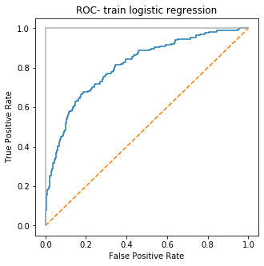

```
AUC score for Logistic Regression-test:  0.7064690026954178
```

```
(<Figure size 360x360 with 1 Axes>,
```

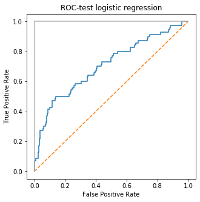

```python
log_train=logreg.predict_proba(x_train)
log_train=log_train[:,1]
false_positive_rate1, true_positive_rate1, threshold1 = roc_curve(y_train, log_train)
print('AUC score for Logistic Regression-train:',roc_auc_score(y_train, log_train))

# Plot ROC curves
plt.subplots(1, figsize=(5,5))
plt.title('ROC- train logistic regression')
plt.plot(false_positive_rate1, true_positive_rate1)
plt.plot([0, 1], ls="--")
plt.plot([0, 0], [1, 0] , c=".7"), plt.plot([1, 1] , c=".7")
plt.ylabel('True Positive Rate')
plt.xlabel('False Positive Rate')
plt.show()


log_test=logreg.predict_proba(x_test)
log_test=log_test[:,1]
false_positive_rate2, true_positive_rate2, threshold2 = roc_curve(y_test, log_test)
print('AUC score for Logistic Regression-test: ', roc_auc_score(y_test, log_test))

# Plot ROC curves
plt.subplots(1, figsize=(5,5))
plt.title('ROC-test logistic regression')
plt.plot(false_positive_rate2, true_positive_rate2)
plt.plot([0, 1], ls="--")
plt.plot([0, 0], [1, 0] , c=".7"), plt.plot([1, 1] , c=".7")
plt.ylabel('True Positive Rate')
plt.xlabel('False Positive Rate')
plt.show()
```

# DECISION TREE MODEL

```python
dt=DecisionTreeClassifier(random_state=1)
#fitmodel
dt.fit(x_train,y_train)

#decision tree for train
dt_prediction1 = dt.predict(x_train)
dt_score1=accuracy_score(y_train,dt_prediction1)
print('ACCURACY FOR DECISION TREE ON TRAIN:-')
print(dt_score1)

#Confusion matrix for the DECISION TREE
print('CONFUSION MATRIX:-')

print(confusion_matrix(y_train, dt_prediction1))

#Let's see how our model performed
print('CLASSIFICATION REPORT:-')

print(classification_report(y_train, dt_prediction1))


#decision tree for test
dt_prediction2 = dt.predict(x_test)
dt_score2=accuracy_score(y_test,dt_prediction2)
print('ACCURACY FOR DECISION TREE ON TEST:-')
print(dt_score2)

#Confusion matrix for the DECISION TREE
print('CONFUSION MATRIX:-')

print(confusion_matrix(y_train, dt_prediction1))

#Let's see how our model performed
print('CLASSIFICATION REPORT:-')

print(classification_report(y_train, dt_prediction1))
```

```
DecisionTreeClassifier(class_weight=None, criterion='gini', max_depth=None,
                       max_features=None, max_leaf_nodes=None,
                       min_impurity_decrease=0.0, min_impurity_split=None,
                       min_samples_leaf=1, min_samples_split=2,
                       min_weight_fraction_leaf=0.0, presort=False,
                       random_state=1, splitter='best')
```

```
ACCURACY FOR DECISION TREE ON TRAIN:-
1.0
CONFUSION MATRIX:-
[[862   0]
 [  0 167]]
CLASSIFICATION REPORT:-
              precision    recall  f1-score   support

           0       1.00      1.00      1.00       862
           1       1.00      1.00      1.00       167

    accuracy                           1.00      1029
   macro avg       1.00      1.00      1.00      1029
weighted avg       1.00      1.00      1.00      1029

ACCURACY FOR DECISION TREE ON TEST:-
0.7052154195011338
CONFUSION MATRIX:-
[[862   0]
 [  0 167]]
CLASSIFICATION REPORT:-
              precision    recall  f1-score   support

           0       1.00      1.00      1.00       862
           1       1.00      1.00      1.00       167

    accuracy                           1.00      1029
   macro avg       1.00      1.00      1.00      1029
weighted avg       1.00      1.00      1.00      1029
```

Sensitivity and specificity of decision tree model

```python
# for train
print('SENSITIVITY FOR DECISION TREE TRAIN:-')
sensitivity1 = 862/(862+0)
print('Sensitivity : ', sensitivity1 )

print('SPECIFICITY FOR DECISION TREE TRAIN:-')
specificity1 = 167/(0+167)
print('Specificity : ', specificity1)

#for test
print('SENSITIVITY FOR DECISON TREE TEST:-')
sensitivity1 = 862/(862+0)
print('Sensitivity : ', sensitivity1 )

print('SPECIFICITY FOR DECISION TREE TEST:-')
specificity1 = 167/(0+167)
print('Specificity : ', specificity1)
```

[output not shown]

ROC CURVE AND AUC OF DECISION TREE MODEL

```python
# dt_model_train=dt.predict_proba(x_train)
dt_model_train=dt_model_train[:,1]
false_positive_rate1, true_positive_rate1, threshold1 = roc_curve(y_train, dt_model_train)
print('AUC score for decision tree-train: ', roc_auc_score(y_train, dt_model_train))

# Plot ROC curves
plt.subplots(1, figsize=(5,5))
plt.title('ROC train - Decision tree')
plt.plot(false_positive_rate1, true_positive_rate1)
plt.plot([0, 1], ls="--")
plt.plot([0, 0], [1, 0] , c=".7"), plt.plot([1, 1] , c=".7")
plt.ylabel('True Positive Rate')
plt.xlabel('False Positive Rate')
plt.show()


dt_model_test=dt.predict_proba(x_test)
dt_model_test=dt_model_test[:,1]
false_positive_rate2, true_positive_rate2, threshold2 = roc_curve(y_test, dt_model_test)
print('AUC score for decision tree-test: ', roc_auc_score(y_test, dt_model_test))

# Plot ROC curves
plt.subplots(1, figsize=(5,5))
plt.title('ROC test - Decision tree')
plt.plot(false_positive_rate2, true_positive_rate2)
plt.plot([0, 1], ls="--")
plt.plot([0, 0], [1, 0] , c=".7"), plt.plot([1, 1] , c=".7")
plt.ylabel('True Positive Rate')
plt.xlabel('False Positive Rate')
plt.show()
```

[output not shown]

# DECISION TREE ON GRID SEARCH

```python
dtc1 = DecisionTreeClassifier(random_state=1)

# choose some parameter combination to try
parameters = {'max_features' : ['log2','sqrt','auto'],
              'max_depth': [2,3,4,5],
              'min_samples_split': [2,3,5],
              'min_samples_leaf': [1,2,3]
             }
# type of scoring used to compare parameter combinations
acc_scorer1 = make_scorer(accuracy_score)
# run the grid search
grid_obj1 = GridSearchCV(dtc1,parameters,scoring = acc_scorer1)
grid_obj1 = grid_obj1.fit(x_train,y_train)
# set the clf to the best combination of parametsrs
dtc1 = grid_obj1.best_estimator_
# create the modelby fitting
dtc1.fit(x_train,y_train)

# prediction on train data
dtc_prediction_train1 = dtc1.predict(x_train)
dtc_score_train1=accuracy_score(y_train,dtc_prediction_train1)
print('ACCURACY ON DECISION TREE WITH GRID SEARCH ON TRAIN:-')
print(dtc_score_train1)

#Confusion matrix for the decision tree
print('CONFUSION MATRIX:-')

print(confusion_matrix(y_train, dtc_prediction_train1))


#Let's see how our model performed
print('CLASIFICATION REPORT:-')

print(classification_report(y_train, dtc_prediction_train1))


# prediction on test data
dtc_prediction_test2 = dtc1.predict(x_test)
dtc_score_test2=accuracy_score(y_test,dtc_prediction_test2)
print('ACCURACY ON DECISION TREE WITH GRID SEARCH ON TEST:-')
print(dtc_score_test2)

#Confusion matrix for the decision tree
print('CONFUSION MATRIX:-')

print(confusion_matrix(y_test, dtc_prediction_test2))

#Let's see how our model performed
print('CLASIFICATION REPORT:-')

print(classification_report(y_test, dtc_prediction_test2))
```

```
DecisionTreeClassifier(class_weight=None, criterion='gini', max_depth=5,
                       max_features='log2', max_leaf_nodes=None,
                       min_impurity_decrease=0.0, min_impurity_split=None,
                       min_samples_leaf=1, min_samples_split=5,
                       min_weight_fraction_leaf=0.0, presort=False,
                       random_state=1, splitter='best')
```

```
ACCURACY ON DECISION TREE WITH GRID SEARCH ON TRAIN:-
0.8649173955296404
CONFUSION MATRIX:-
[[846  16]
 [123  44]]
CLASIFICATION REPORT:-
              precision    recall  f1-score   support

           0       0.87      0.98      0.92       862
           1       0.73      0.26      0.39       167

    accuracy                           0.86      1029
   macro avg       0.80      0.62      0.66      1029
weighted avg       0.85      0.86      0.84      1029

ACCURACY ON DECISION TREE WITH GRID SEARCH ON TEST:-
0.8072562358276644
CONFUSION MATRIX:-
[[352  19]
 [ 66   4]]
CLASIFICATION REPORT:-
              precision    recall  f1-score   support

           0       0.84      0.95      0.89       371
           1       0.17      0.06      0.09        70

    accuracy                           0.81       441
   macro avg       0.51      0.50      0.49       441
weighted avg       0.74      0.81      0.76       441
```

Sensitivity and specificity of GRID SEARCH Decision tree model

```python
# for train
print('SENSITIVITY FOR DECISION TREE TRAIN:-')
sensitivity1 = 846/(846+123)
print('Sensitivity : ', sensitivity1 )

print('SPECIFICITY FOR DECISION TREE TRAIN:-')
specificity1 = 16/(16+44)
print('Specificity : ', specificity1)

#for test
print('SENSITIVITY FOR DECISION TREE TEST:-')
sensitivity1 = 352/(352+66)
print('Sensitivity : ', sensitivity1 )

print('SPECIFICITY FOR DECISION TREE TEST:-')
specificity1 = 4/(4+19)
print('Specificity : ', specificity1)
```

```
SENSITIVITY FOR DECISION TREE TRAIN:-
Sensitivity :  0.8730650154798761
SPECIFICITY FOR DECISION TREE TRAIN:-
Specificity :  0.26666666666666666
SENSITIVITY FOR DECISION TREE TEST:-
Sensitivity :  0.8421052631578947
SPECIFICITY FOR DECISION TREE TEST:-
Specificity :  0.17391304347826086
```